# An Ordinal Model for Diagnosing Middle Ear Disease in Infants

In this analysis I develop an ordinal prediction model for diagnosing middle ear disease in infants. “Ordinal” means that there is a systematic ordering of the outcome, for example, “normal”, “mild”, or “severe” disease.

You can see the code that produced the output by clicking the ‘code’ buttons on the right of the page. This is a simplified version of an analysis that I did for my PhD project, the full script is available [here](https://github.com/Josh-Myers/Ordinal-Model-12-Months/blob/master/analysis.R).

## Research Question

Infants with onset of middle ear disease early in life are at greater risk of recurrent and chronic infections throughout childhood. Diagnostic tools for identifictaion of middle ear disease in infancy could help provide timely diagnosis and appropriate management of affected children.

Absorbance is an innovative test for middle ear disease that uses a high-dimensional response to measure the function of the middle ear over a wide range of frequencies (pitches). An advantage of this technology is that it is high resolution, capturing detailed information about the middle ear, but the amount of information generated by the test also makes interpreting results difficult for clinicians. My research goal was to develop an objective method for interpreting test results to help clinicians diagnose middle ear disease in infants.

## Analysis

### *Data wrangling and exploration*

I first wrangled the data and plotted average test results (absorbance) stratified by levels of the outcome (normal, mild, and severe). The absorbance test measures middle ear function over a wide range of frequencies (226 to 8000 Hz). The figure below shows that there does appear to be an ordinal relationship in the data, with mild generally falling between normal and severe levels of the outcome.

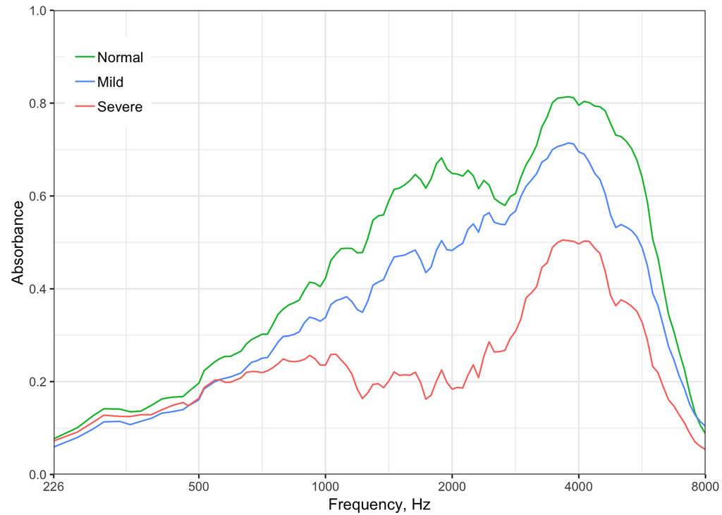

```r
library(MyersMisc)
library(plyr)
library(tidyr)
library(tidyverse)
library(rms)

# load and wrangle data
abs.2 = readRDS('abs.2.rds')
abs.24 = readRDS('abs.24.rds')
abs.2 = select(abs.2, -abs226)
abs.2 = filter(abs.2, !is.na(rs))
abs.24 = filter(abs.24, !is.na(rs))
abs.2$rs[abs.2$rs == 'CNT'] = NA
abs.24$rs[abs.24$rs == 'CNT'] = NA
abs.2$rs = droplevels(abs.2$rs)
abs.24$rs = droplevels(abs.24$rs)
abs.2 = filter(abs.2, !is.na(rs) & !is.na(abs250))
abs.24 = filter(abs.24, !is.na(rs) & !is.na(abs226))
number_infants_study_sample = distinct(abs.2, sub.id, .keep_all = TRUE)

# Plot of normal/Mild/Severe
rs.plot.df = abs.24
rs.plot.df$rs = factor(rs.plot.df$rs, levels = c('Pass', 'Mild', 'Severe'))
rs.plot.df$rs <- revalue(rs.plot.df$rs, c("Pass" = "Normal",
                                "Mild" = "Mild",
                                "Severe" = "Severe"))

rs.plot.df <- select(rs.plot.df, rs, starts_with('abs'))
colnames(rs.plot.df) <- c("rs", "226.00", "257.33", "280.62", "297.30", "324.21", "343.49", "363.91", "385.55", "408.48", "432.77", "458.50",
                      "471.94", "500.00", "514.65", "545.25", "561.23", "577.68", "594.60", "629.96", "648.42", "667.42", "686.98",
                      "707.11", "727.83", "749.15", "771.11", "793.70", "816.96", "840.90", "865.54", "890.90", "917.00", "943.87",
                      "971.53", "1000.00", "1029.30", "1059.46", "1090.51", "1122.46", "1155.35", "1189.21", "1224.05", "1259.92",
                      "1296.84", "1334.84", "1373.95", "1414.21", "1455.65", "1498.31", "1542.21", "1587.40", "1633.92", "1681.79",
                      "1731.07", "1781.80", "1834.01", "1887.75", "1943.06", "2000.00", "2058.60", "2118.93", "2181.02", "2244.92",
                      "2310.71", "2378.41", "2448.11", "2519.84", "2593.68", "2669.68", "2747.91", "2828.43", "2911.31", "2996.61",
                      "3084.42", "3174.80", "3267.83", "3363.59", "3462.15", "3563.59", "3668.02", "3775.50", "3886.13",
                      "4000.00", "4117.21", "4237.85", "4362.03", "4489.85", "4621.41", "4756.83", "4896.21", "5039.68", "5187.36",
                      "5339.36", "5495.81", "5656.85", "5822.61", "5993.23", "6168.84", "6349.60", "6535.66", "6727.17", "6924.29",
                      "7127.19", "7336.03", "7550.99", "7772.26", "8000.00")

rs.plot.df <- group_by(rs.plot.df, rs)
abs.mean <- summarise_all(rs.plot.df, funs(mean))
abs.mean <- gather(abs.mean, Frequency, absorbance, 2:108)
ggplot(abs.mean, aes(x=as.numeric(Frequency), y=absorbance, group=rs, colour=rs)) +
  theme_bw() +
  scale_colour_manual(values = c("Normal" = "#00BA38", "Mild" = "#619CFF", "Severe" = "#F8766D")) +
  geom_line()  +
  xlab("Frequency, Hz") +
  ylab("Absorbance") +
  scale_x_log10(expand=c(0, 0), breaks=c(226, 500, 1000, 2000, 4000, 8000))  +
  scale_y_continuous(expand=c(0, 0), breaks=c(0, 0.2, 0.4, 0.6, 0.8, 1), limits=c(0, 1)) +
  theme(legend.title=element_blank(), legend.text=element_text(size=10), legend.justification=c(0,1),
        legend.position=c(0,1)) +
  theme(axis.title.y = element_text(vjust = 0.6)) +
  theme(plot.margin=unit(c(0.5, 0.8, 0.1, 0.5),"lines")) +
  theme(legend.title=element_blank(), legend.justification=c(1,0), legend.position=c(0.15,0.75))
```

I created features from the data for modeling by averaging the results into 1/2 octave frequency resolution bands which reduced the number of variables from >100 to 11. I then chose features based on prior research, which has found an ordinal relationship in absorbance results from 1000 to 6000 Hz. The figure above shows that there was an ordinal relationship (mild between normal and severe) over this frequency range in this dataset also. The final candidate variables for the model were absorbance at 1000, 1414, 2000, 2828, 4000, and 5657 Hz.

### *Checking assumptions*

I chose to model the data using proportional odds logistic regression. This model assumes that the same regression coefficients (the number that you multiply each variable by in the predictive algorithm) can be used to predict the outcome regardless of the level of the outcome being predicted (mild or severe).

I checked this assumption by plotting the raw data averages against the expected values under the assumption of proportional odds for each of the candidate variables. The solid lines and circles represent the raw data averages, and the dashed lines the expected values under the assumption of proportional odds. The trend in the solid lines should be monotonic to satisfy the assumption of proportional odds. The figures below show that the solid lines were monotonic for all variables, and the expected values were very close to the simple means for all variables except for 2828 Hz. Overall, the assumption of proportional odds was satisfied for these variables.

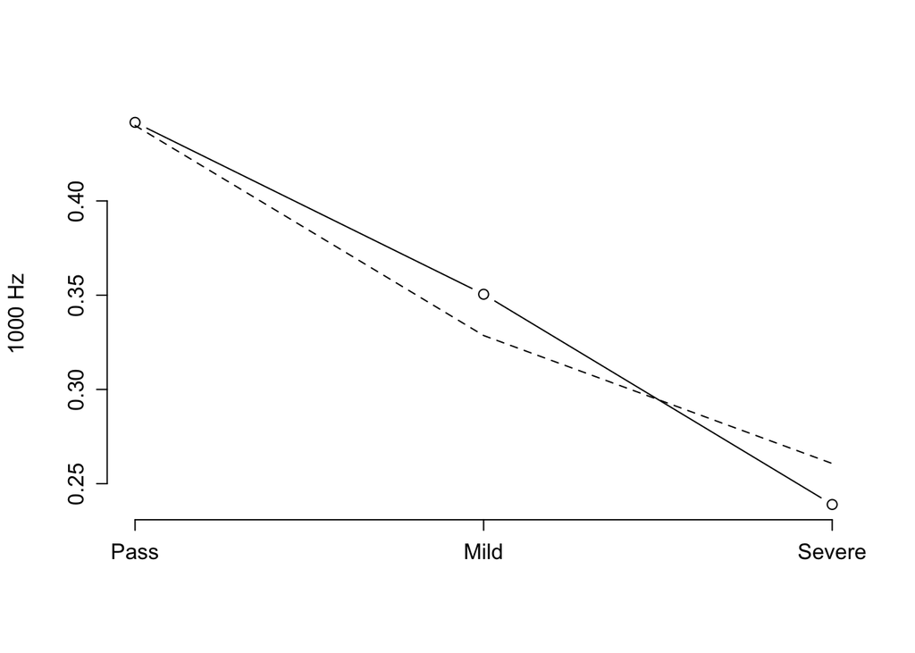

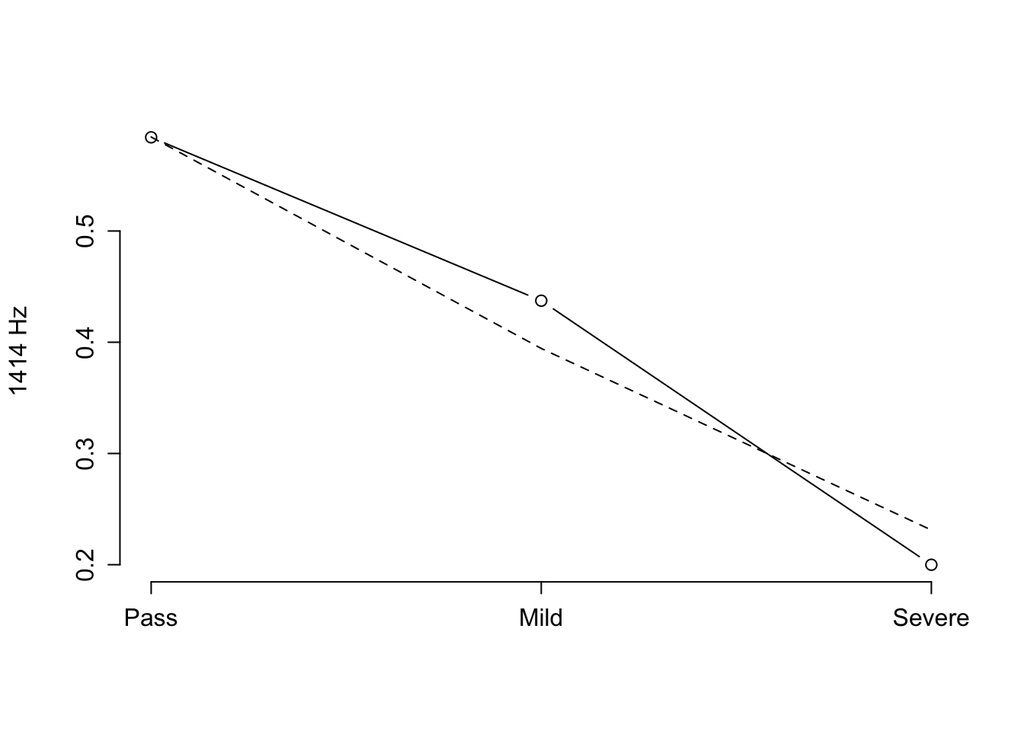

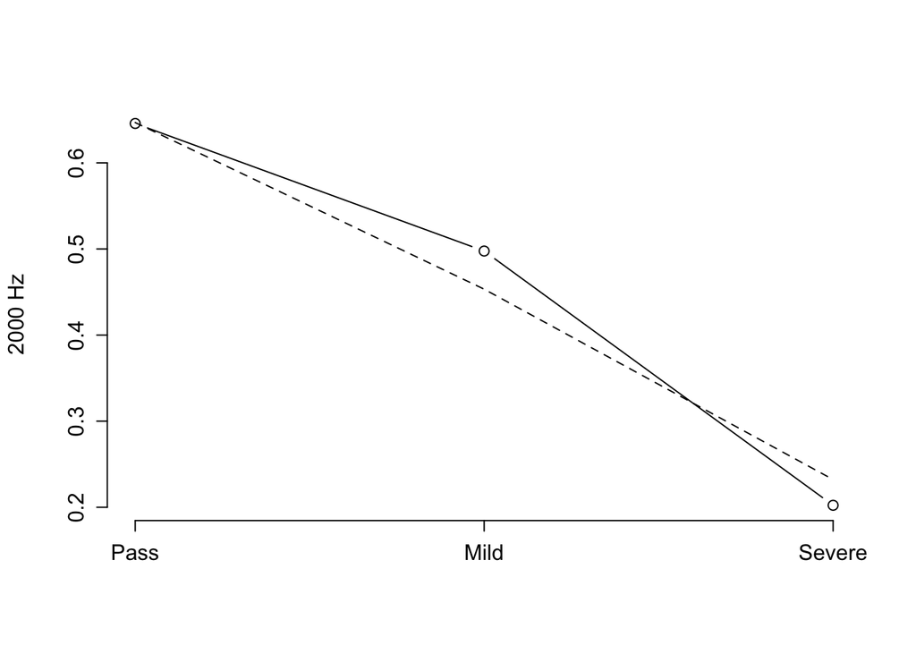

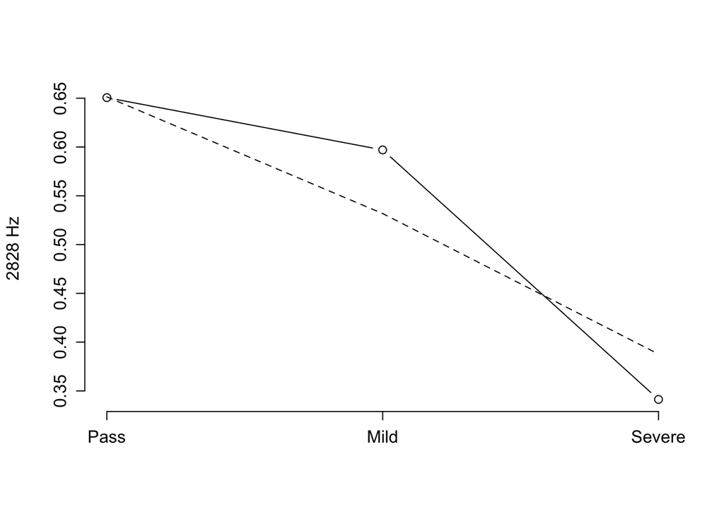

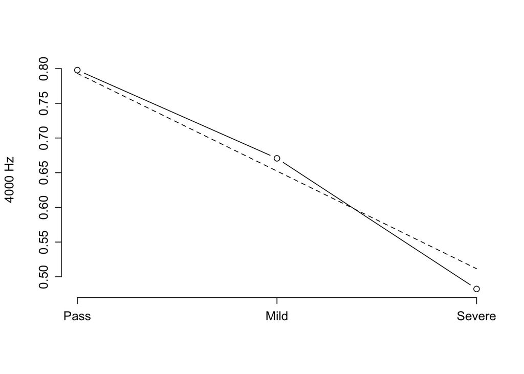

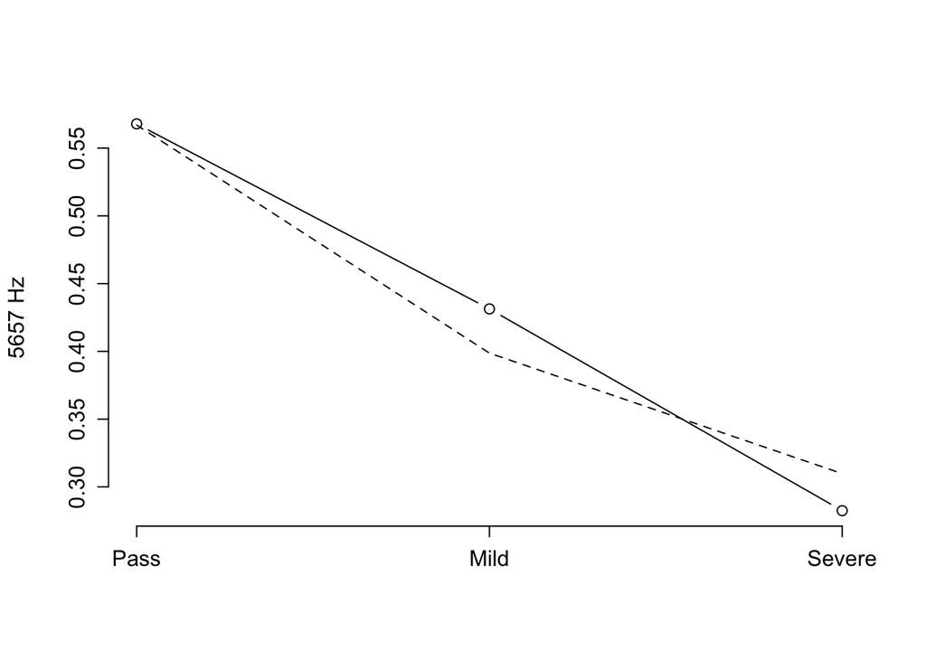

```r
abs.2$rs = factor(abs.2$rs, levels = c('Pass', 'Mild', 'Severe'))
MyersMisc:::My.plot.xmean.ordinaly(rs ~ abs1000, cr=F, topcats=2, subn = F, data = abs.2, xlab = "", ylab = "1000 Hz")
MyersMisc:::My.plot.xmean.ordinaly(rs ~ abs1414, cr=F, topcats=2, subn = F, data = abs.2, xlab = "", ylab = "1414 Hz")
MyersMisc:::My.plot.xmean.ordinaly(rs ~ abs2000, cr=F, topcats=2, subn = F, data = abs.2, xlab = "", ylab = "2000 Hz")
MyersMisc:::My.plot.xmean.ordinaly(rs ~ abs2828, cr=F, topcats=2, subn = F, data = abs.2, xlab = "", ylab = "2828 Hz")
MyersMisc:::My.plot.xmean.ordinaly(rs ~ abs4000, cr=F, topcats=2, subn = F, data = abs.2, xlab = "", ylab = "4000 Hz")
MyersMisc:::My.plot.xmean.ordinaly(rs ~ abs5657, cr=F, topcats=2, subn = F, data = abs.2, xlab = "", ylab = "5657 Hz")
```

### *Fitting and interpreting the model*

I then fitted the model, and plotted the amount of $\chi^2$ (chi-square, a type of statistic) that each variable contributed. The higher the amount of $\chi^2$, the more important the variable in the model. The figure below shows that the most important features in the model were absorbance at 1000, 2000 and 5657 Hz.

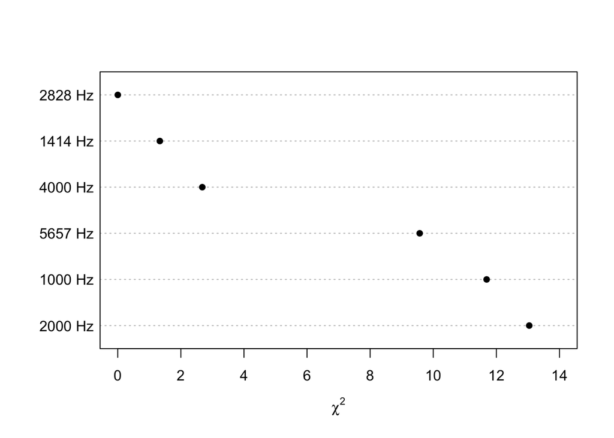

```r
raw.dd <- datadist(abs.2)
options(datadist="raw.dd")
f <- lrm(rs ~ abs1000 + abs1414 + abs2000 + abs2828 + abs4000 + abs5657, data = abs.2, x = T, y = T)
r = robcov(f, abs.2$sub.id)
plot(anova(r), what="chisq", margin = "", newnames = c("1000 Hz", "1414 Hz", "2000 Hz", "2828 Hz", "4000 Hz","5657 Hz"), xlim = c(0, 14))
```

### *Evaluating model performance*

I then evaluated the performance of the model and validated it with bootstrap resampling (a process of sampling the data with replacement). Model performance was evaluated with measures of *calibration* and *discrimination*. Calibration assesses the quality of predictions, for example, subjects with predicted probability by the model of 0.5 should actually have the condition around 50% of the time. Calibration was assessed with calibration curves for each level of the outcome (mild and severe).

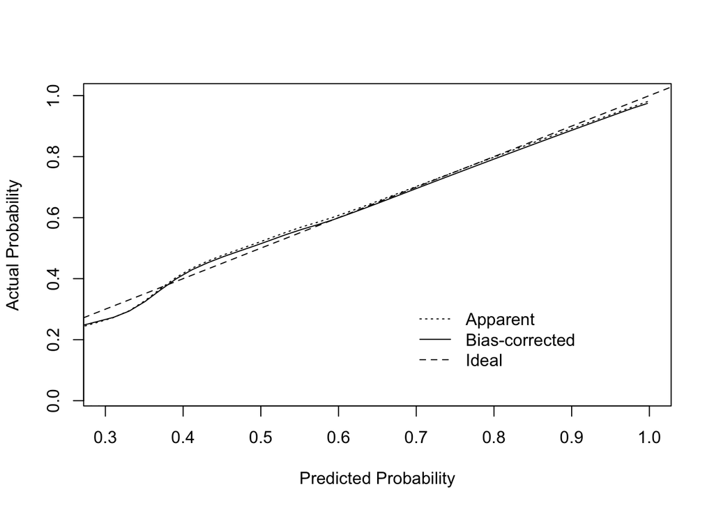

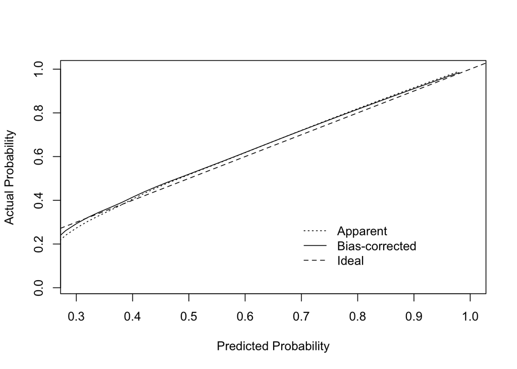

```r
r.pred <- predict(r, type = "fitted")
validate(r, B = 500)
cal1 = calibrate(r, B = 500, kint = 1) # calibrate for Y >= Mild
plot(cal1, scat1d.opts=list(nhistSpike=0, side=1, frac=0.00, tck=0), xlim = c(0.3, 1), subtitles = F, xlab = "Predicted Probability", ylab = "Actual Probability")
cal2 = calibrate(r, B = 500, kint = 2) # calibrate for Y >= Severe
plot(cal2, scat1d.opts=list(nhistSpike=0, side=1, frac=0.00, tck=0), xlim = c(0.3, 1), subtitles = F, xlab = "Predicted Probability", ylab = "Actual Probability")

val <- validate(r, B=500)
full <- val[[1]]
train <- val[[12]]
test <- val[[23]]
dxy.to.auc <- function(x) {
  0.5*(x+1)
  }
auc.full <- round(dxy.to.auc(full), 3)
auc.train <- round(dxy.to.auc(train), 3)
auc.test <- round(dxy.to.auc(test), 3)
opt <- auc.train - auc.test
opt.cor <- auc.full - opt
auc.df <- c(auc.full, auc.train, auc.test, opt, opt.cor)
auc.df.names <- c("full", "train", "test", "opt", "opt.cor")
auc.res <- cbind.data.frame(auc.df.names, auc.df)
auc = auc.res[5,]
```

Discrimination is how well the model distinguishes between normal and diseased cases. Discrimination was assessed with the *c*-index. A model with *c*-index of 0.5 is no better than chance, and a *c*-index of 1 perfectly discriminates between levels of the outcome. The *c*-index is the probability that for two subjects selected at random, one normal and one diseased, the model assigned higher probability of disease to the subject with the condition. The *c*-index of the model was 0.919, and opt.cor, 0.913 after being corrected for bias. This is a very accurate model, with limited bias, meaning that our model has not overfit the data.

## Applying the model

Below is a figure of applying the model to absorbance results from an infant. The graph plots the absorbance test result (red line) against the 90% normal range (shaded region), and provides the most likely diagnosis predicted by the model. It also presents the probability (Prob) that the subject has that condtion in parentheses. For this subject, the most likely diagnosis was severe dysfunction with probability of 0.89, meaning that it is very likely that this infant has severe middle ear disease.

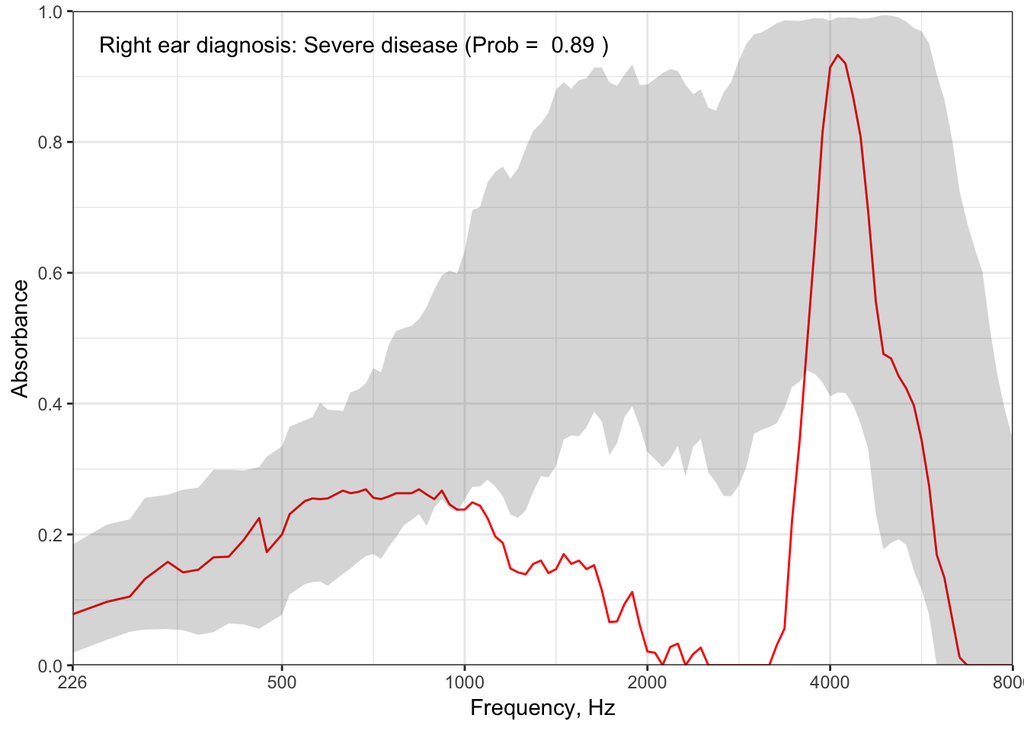

```r
# create 90% normal range
norm.24 = abs.24
norm.24 = select(norm.24, rs, starts_with('abs'))
norm.24 <- group_by(norm.24, rs)
abs.median <- summarise_all(norm.24, funs(median))
abs.05 <- summarise_all(norm.24, funs(quantile(., probs = (0.05))))
abs.95 <- summarise_all(norm.24, funs(quantile(., probs = (0.95))))
abs.90 <- rbind(abs.median, abs.05, abs.95)
abs.90 <- data.frame(abs.90)
names1 = c("rs", "226.00", "257.33", "280.62", "297.30", "324.21", "343.49", "363.91", "385.55", "408.48", "432.77", "458.50",
                       "471.94", "500.00", "514.65", "545.25", "561.23", "577.68", "594.60", "629.96", "648.42", "667.42", "686.98",
                       "707.11", "727.83", "749.15", "771.11", "793.70", "816.96", "840.90", "865.54", "890.90", "917.00", "943.87",
                       "971.53", "1000.00", "1029.30", "1059.46", "1090.51", "1122.46", "1155.35", "1189.21", "1224.05", "1259.92",
                       "1296.84", "1334.84", "1373.95", "1414.21", "1455.65", "1498.31", "1542.21", "1587.40", "1633.92", "1681.79",
                       "1731.07", "1781.80", "1834.01", "1887.75", "1943.06", "2000.00", "2058.60", "2118.93", "2181.02", "2244.92",
                       "2310.71", "2378.41", "2448.11", "2519.84", "2593.68", "2669.68", "2747.91", "2828.43", "2911.31", "2996.61",
                       "3084.42", "3174.80", "3267.83", "3363.59", "3462.15", "3563.59", "3668.02", "3775.50", "3886.13",
                       "4000.00", "4117.21", "4237.85", "4362.03", "4489.85", "4621.41", "4756.83", "4896.21", "5039.68", "5187.36",
                       "5339.36", "5495.81", "5656.85", "5822.61", "5993.23", "6168.84", "6349.60", "6535.66", "6727.17", "6924.29",
                       "7127.19", "7336.03", "7550.99", "7772.26", "8000.00")

colnames(abs.90) <- names1
stats.col <- c("median", "median", "median", "five", "five", "five", "ninety5", "ninety5", "ninety5")
abs.90 <- cbind.data.frame(abs.90, stats.col)
abs.90.long <- gather(abs.90, Frequency, absorbance, 2:108)
abs.90.long <- spread(abs.90.long, stats.col, absorbance)
abs.90.long$Frequency <- as.numeric(abs.90.long$Frequency)
abs.90.long$rs = as.character(abs.90.long$rs)
abs.90.long = filter(abs.90.long, rs == 'Pass')
freq.num = as.numeric(names1[-1])
# example
eg2 = filter(abs.2, sub.id==416, ear=="R")
eg.prob.ind2 = round(predict(r, eg2, type = "fitted.ind"), 2)
diagnosis = c("Normal", "Mild", "Severe")[which.max(c(eg.prob.ind2))]
probability = max(eg.prob.ind2)
eg.abs2 = filter(abs.24, sub.id==416, ear=="R")
eg.abs2 = dplyr::select(eg.abs2, abs226:abs8000)
names(eg.abs2) = freq.num
eg.abs.long2 <- gather(eg.abs2, Frequency, Absorbance, 1:107)
eg.abs.long2$Frequency = as.numeric(eg.abs.long2$Frequency)

ggplot(eg.abs.long2) +
  scale_x_log10(expand=c(0, 0), breaks=c(226, 500, 1000, 2000, 4000, 8000))  +
  geom_line(aes(x= Frequency, y=Absorbance), data = eg.abs.long2, colour="red") +
  geom_ribbon(data=abs.90.long, aes(x = Frequency, ymin = five, ymax = ninety5, linetype=NA), alpha = 0.2, show.legend = F) +
  xlab("Frequency, Hz") +
  ylab("Absorbance") +
  scale_y_continuous(expand=c(0, 0), breaks=c(0, 0.2, 0.4, 0.6, 0.8, 1), limits=c(0, 1)) +
  theme(legend.text=element_text(size=10), legend.justification=c(0,1)) +
  theme(axis.title.y = element_text(vjust = 0.6)) +
  theme(plot.margin=unit(c(0.5, 0.8, 0.1, 0.5),"lines")) +
  theme(plot.title = element_text(hjust = 0.5)) +
  theme(plot.title = element_text(lineheight=.8, face="bold")) +
  theme(plot.title = element_text(vjust=2)) +
  annotate("text", x = 250, y = c(0.95), label = paste("Right ear diagnosis:", diagnosis, "disease (Prob = ", probability, ")"), hjust = 0) +
  theme_bw()
```

I made the model available to clinicians by implementing it as a web application which is available [here](https://joshmyers.shinyapps.io/WAIPredictions/). To try out the model choose “10-16 months” from the “Select age” menu, then click one of the “12 months” example files to download to your compluter (this is the test result that is saved by the clinican), and then upload the file with the “Browse” button to make a prediction based on the results saved in the file.